# Cyclistic

This is the capstone project of the Google Data Analytics Professional Certificate course, which aims to demonstrate my technical and analytical skills for the entry-level Data Analyst Position.

In this BI project I used the R (tidyverse packages) to clean, manipulate and analyze the dataset, and I also create an interactive dashboard in Tableau, in order to create appealing visualizations that allow comparing the type of behavior of the two types of users: casual riders and annual members.

#### Summary

1. Scope
2. About the data
3. Data Cleaning and Manipulation
4. Summary of Analysis
5. Key Findings and Supporting Visualizations
6. Recommendations

### 1. Scope

#### Scenario

Cyclistic is a bike-sharing company in Chicago with two different sorts of clients. Casual riders are customers who buy single-ride or full-day passes, whereas members are customers who buy annual subscriptions. Financial researchers at Cyclistic have determined that annual members are significantly more profitable than casual riders. The director of marketing believes the company’s future success depends on maximizing the number of annual memberships. Therefore, your team wants to understand how casual riders and annual members use Cyclistic bikes differently, in order to convert casual riders into members.

#### Business task

Analyze Cyclist’s historical trip data from 2022, in order to identify trends on the different behavior between the casual riders and the annual members.

#### Stakeholders

- Primary stakeholders: Cyclistic director of marketing and the Cyclistic executive team.
- Secondary stakeholders: Cyclistic marketing analytics team.

#### Deliverables

- Documentation of cleaning and manipulation data;
- Summary of analysis;
- Supporting visualizations and key findings;
- Recommendations.

### 2. About the data

#### Source

It is possible to access Cyclistic historical trip data through this [link](https://divvy-tripdata.s3.amazonaws.com/index.html). The data sets have a different name because Cyclistic is a fictional company. The data has been made available by Motivate International Inc. under this [license](https://ride.divvybikes.com/data-license-agreement).

For the purposes of this study, we will use the 12 CSV files (January - December) referring to the trip history in 2022.

#### Quality

Bearing in mind that this is primary data collected by Cyclistic, we can assume that the data is reliable, original, comprehensive and current. With regard to its integrity, in the data cleaning process, an analysis will be made of various situations, namely, duplicate observations, missing or inconsistent values, validity of data range, data type conversions, to ensure that the data is accurate, complete, consistent, trustworthy and aligned with the business objective.

#### Structure

Data is organized in a tabular structure and all CSV files share all the same columns:

- ride_id
- rideable_type
- started_at
- ended_at
- start_station_name
- start_station_id
- end_station_name
- end_station_id
- start_lat
- start_lng
- end_lat
- end_lng
- member_casual

#### Prepare

Rstudio was the tool of choice to clean, manipulate and analyze the data. In this sense, it was initially necessary to import the data of the 12 CSV files into RStudio:

```
Cyclistic_012022 <- read_csv("Desktop/Data Analytics/Google Data Analytics Professional Certificate/8 - Google Data Analytics Case Study/Capstone Project/Cyclistic/Raw data - CSV files/202201-divvy-tripdata.csv",
                             col_types = cols(ride_id = col_character(),
                                              rideable_type = col_character(),
                                              started_at = col_datetime(),
                                              ended_at = col_datetime(),
                                              start_station_name = col_character(),
                                              start_station_id = col_character(),
                                              end_station_name = col_character(),
                                              end_station_id = col_character(),
                                              start_lat = col_double(), start_lng = col_double(),
                                              end_lat = col_double(), end_lng = col_double(),
                                              member_casual = col_character()))
```

Next, the various columns of the different CSV files were compared to ensure that they all shared exactly the same name:

```
compare_df_cols(Cyclistic_012022, Cyclistic_022022, Cyclistic_032022, Cyclistic_042022, Cyclistic_052022, Cyclistic_062022, Cyclistic_072022, Cyclistic_082022, Cyclistic_092022, Cyclistic_102022, Cyclistic_112022, Cyclistic_122022)
```

The 12 data frames are combined into a single annual data frame:

```
Cyclistic_2022 <- bind_rows(Cyclistic_012022, Cyclistic_022022, Cyclistic_032022, Cyclistic_042022, Cyclistic_052022, Cyclistic_062022, Cyclistic_072022, Cyclistic_082022, Cyclistic_092022, Cyclistic_102022, Cyclistic_112022, Cyclistic_122022)
```

And finally, for a better understanding of the data frame, we rename the column names:

```
Cyclistic_2022 <- rename(Cyclistic_2022, bike_type=rideable_type, user_type=member_casual, start_latitude=start_lat, end_latitude=end_lat, start_longitude=start_lng, end_longitude=end_lng)
```

### 3. Data cleaning and manipulation

In order to verify the need for data cleaning, all columns of interest, according to their specificity, were checked for the existence of null values, duplicate entries, validity of data range and unique values. Everything was in order. Below are some examples of these checks:

- Check null values

```
Cyclistic_2022 %>% filter(is.na(ride_id))
Cyclistic_2022 %>% filter(is.na(bike_type))
```

- Check duplicated entries

```
Cyclistic_2022 %>% filter(duplicated(ride_id))
```

- Check validity of data range

```
valid_start_at <- ymd_hms("2022-01-01 00:00:00")
valid_end_at <- ymd_hms("2022-12-31 23:59:59")

Cyclistic_2022 %>% filter(started_at < valid_start_at | started_at > valid_end_at)
```

- Check unique values

```
Cyclistic_2022 %>% select(bike_type) %>% unique()
Cyclistic_2022 %>% select(user_type) %>% unique()
```

Next, only the columns of interest were selected for analysis:

```
Cyclistic_2022_v2 <- Cyclistic_2022 %>%
  select(ride_id, bike_type, started_at, ended_at, user_type)
```

Then a ride duration column was created:

```
Cyclistic_2022_v2$ride_duration <- difftime(strptime(Cyclistic_2022_v2$ended_at, "%Y-%m-%d %H:%M:%S"),
                                             strptime(Cyclistic_2022_v2$started_at, "%Y-%m-%d %H:%M:%S"))
```

And all observations with ride duration less than or equal to zero were removed:

```
Cyclistic_2022_v3 <- Cyclistic_2022_v2 %>% filter(ride_duration > 0)
```

Finally, in order to allow a more specific analysis, new columns were created such as date, month, day of the week, start hour, season and time of day:

```
Cyclistic_2022_v3$date <- as.Date(Cyclistic_2022_v3$started_at)
Cyclistic_2022_v3$month <- format(as.Date(Cyclistic_2022_v3$date), "%m")
Cyclistic_2022_v3 <-Cyclistic_2022_v3 %>% mutate(month =
                                                   case_when(month == "01" ~ "January",
                                                             month == "02" ~ "February",
                                                             month == "03" ~ "March",
                                                             month == "04" ~ "April",
                                                             month == "05" ~ "May",
                                                             month == "06" ~ "June",
                                                             month == "07" ~ "July",
                                                             month == "08" ~ "August",
                                                             month == "09" ~ "September",
                                                             month == "10" ~ "October",
                                                             month == "11" ~ "November",
                                                             month == "12" ~ "December"))

Cyclistic_2022_v3$weekday <- format(as.Date(Cyclistic_2022_v3$date), "%A")
Cyclistic_2022_v3$day <- format(as.Date(Cyclistic_2022_v3$date), "%d")
Cyclistic_2022_v3$start_hour <- hour(Cyclistic_2022_v3$started_at)
Cyclistic_2022_v3 <-Cyclistic_2022_v3 %>% mutate(season =
                                             case_when(month == "01" ~ "Winter",
                                                       month == "02" ~ "Winter",
                                                       month == "03" ~ "Spring",
                                                       month == "04"  ~ "Spring",
                                                       month == "05"  ~ "Spring",
                                                       month == "06"  ~ "Summer",
                                                       month == "07" ~ "Summer",
                                                       month == "08" ~ "Summer",
                                                       month == "09" ~ "Fall",
                                                       month == "10" ~ "Fall",
                                                       month == "11" ~ "Fall",
                                                       month == "12" ~ "Winter"))

Cyclistic_2022_v3 <- Cyclistic_2022_v3 %>% mutate(time_of_day =
                                             case_when(start_hour == "0" ~ "Night",
                                                       start_hour == "1" ~ "Night",
                                                       start_hour == "2" ~ "Night",
                                                       start_hour == "3" ~ "Night",
                                                       start_hour == "4" ~ "Night",
                                                       start_hour == "5" ~ "Night",
                                                       start_hour == "6" ~ "Morning",
                                                       start_hour == "7" ~ "Morning",
                                                       start_hour == "8" ~ "Morning",
                                                       start_hour == "9" ~ "Morning",
                                                       start_hour == "10" ~ "Morning",
                                                       start_hour == "11" ~ "Morning",
                                                       start_hour == "12" ~ "Afternoon",
                                                       start_hour == "13" ~ "Afternoon",
                                                       start_hour == "14" ~ "Afternoon",
                                                       start_hour == "15" ~ "Afternoon",
                                                       start_hour == "16" ~ "Afternoon",
                                                       start_hour == "17" ~ "Afternoon",
                                                       start_hour == "18" ~ "Evening",
                                                       start_hour == "19" ~ "Evening",
                                                       start_hour == "20" ~ "Evening",
                                                       start_hour == "21" ~ "Evening",
                                                       start_hour == "22" ~ "Evening",
                                                       start_hour == "23" ~ "Evening"))
```

### 4. Summary of Analysis

Taking into account that the business task is to identify the different trends in the behavior of the two types of Cyclistic users, we analyzed the following key metrics:

**Total Rides by User Type**

[output not shown]

**Observations:**

- Members had the most amount of the rides at 59% of total rides.

**Total Rides by bike type and user type**

```
Cyclistic_2022_v3 %>%
  group_by(user_type, bike_type) %>%
  count(bike_type)
```

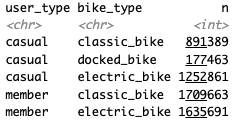

**Observations:**

- Members have a slight preference for classic bikes, while casual users prefer electric bikes.
- Docked bikes are underused compared to the other two options.

**Average Ride Duration by User Type**

[output not shown]

**Observations:**

- Casual users tend to have longer bicycle rides, on average more than twice as long as member users.

**Sum of Ride Duration by User Type**

[output not shown]

**Observations:**

- Of the total riding time in 2022, casual users cycled the longest.

Based on the above, it is possible to identify that members took a greater number of rides throughout the year 2022, however, the rides of casual users are on average longer. When it comes to total time of the rides, casual users have an advantage with about 62% of the total time of the rides.

Then, we went to analyze in detail the difference between the two types of users taking into account different timeframes.

### 5. Supporting visualizations and key findings

Using Tableau, we’re able to plot several graphs in different timeframes, analyse them and draw some conclusions.

An interactive dashboard with all supporting views and conclusions has been created, which is available from this [link](https://public.tableau.com/app/profile/diogo.ferreira1451/viz/Cyclistic_bikeshare_2022/Cyclistic_2022_Analysis).

#### Percentage of Rides per Season

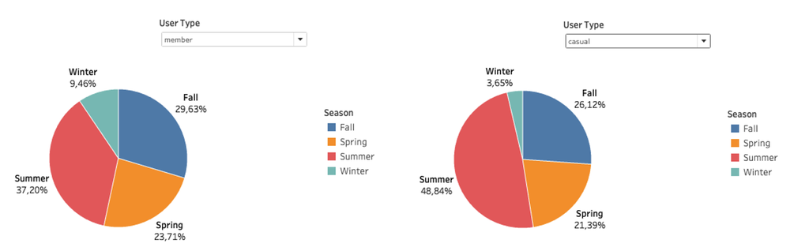

**Observations:**

- The use of the service by both members and casual users has a similar trend throughout the seasons, that is, the most popular season is Summer, followed by Fall, Spring, and the least popular season is Winter.
- In the case of casual users, it appears that there is a use of the service above the total average value in summer (48.84%), whereas in Winter the use of the service is lower (3.65%).
- Members have a more balanced distribution taking into account the trend indicated above.

#### Total Rides by Month

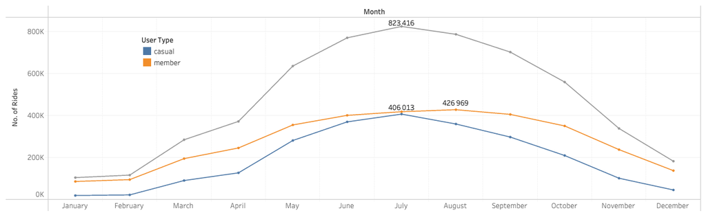

**Observations:**

- Members ride more than casual users every month throughout 2022.
- It can be seen that from March onwards there begins to be an increase in the number of rides per month, a growing trend that culminates in the Summer (July for casual riders, and in August for members). Then follows a downward trend in the number of rides until the end of the year.
- The months of January and February are relatively constant for both groups of users.

#### Percentage of Rides per Weekday

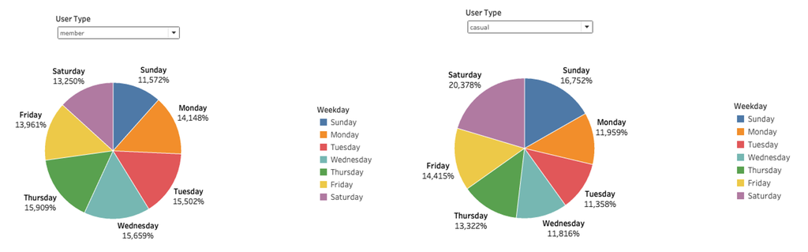

**Observations:**

- Members have the highest percentage of rides on Thursday (15.91%), while for casual users it is on Saturday (20.38%).

#### Total Rides by Weekday

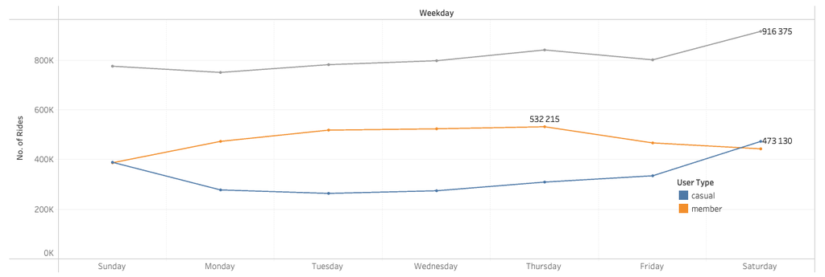

**Observations:**

- The amount of members rides is higher on weekdays, while the amount of casual rides is higher on weekends.
- Member rides increase at the start of the week, peaking during the middle of the week (Thursday) and then decreasing.
- Casual rides have the reverse trend, peaking during the weekend (Saturday) and then decreasing during the week.

#### Percentage of Rides per Time of Day

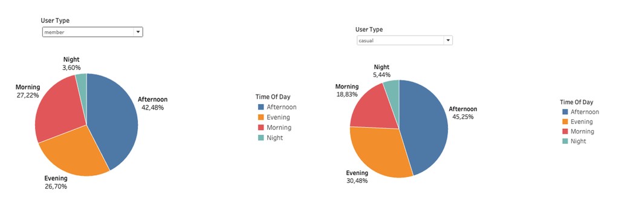

**Observations:**

- Both members and casual users have a higher percentage of rides during afternoon (12 PM - 5 PM).

#### Total Rides by Day Hour

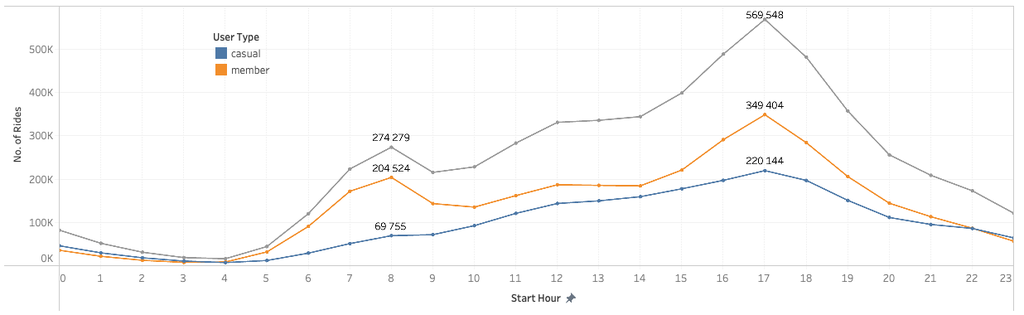

**Observations:**

- Except between the hours of 10 PM and 4 AM, when both groups execute a comparably low number of rides, members typically surpass casuals in terms of the number of rides.
- At peak commute times, more rides are performed by members (7-8 AM and 4-5 PM).
- In the case of casual users, from 6 AM there is a progressive increase in the number of rides, with a stabilization between 8-9 AM, and reaching the peak of rides at 5 PM.

### 6. Recommendations

Here are some recommendations that can be implemented to convert casual riders to annual members:

- Start promotional initiatives in the summer (from June to August).
- Hold promotions for memberships over the weekends to attract more casual riders.
- Raise the cost of renting bikes, especially electric bikes, for weekend casual riders.
- Develop some educational banners and promotions to enlighten casual riders about the cost-effectiveness of using Cyclistic bikes as an annual member for their everyday commute.